# Análise Preditiva de Óbitos Por Doenças Crônicas não Transmitíveis

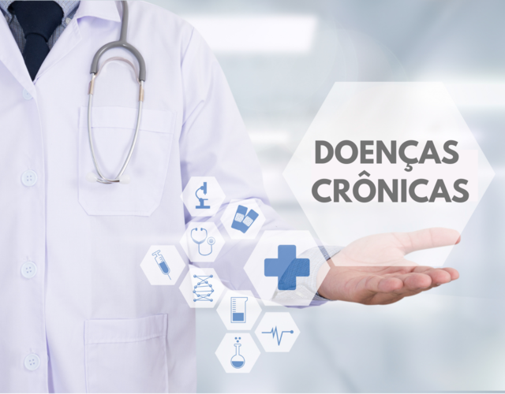

# 1. Contexto

Em um hospital, os administradores estão preocupados com o aumento do número de óbitos de pacientes devido a doenças crônicas. Eles desejam implementar medidas preventivas e intervenções precoces para melhorar os resultados dos pacientes.

# 2. Problema proposto

O hospital deseja identificar padrões e fatores de risco associados à mortalidade por doenças crônicas com base nos dados disponíveis, a fim de desenvolver estratégias de intervenção mais eficazes.

| # | Pergunta | Descrição |
| --- | --- | --- |
| 1 | Quem? | Pacientes do hospital, equipe médica e administradores |
| 2 | O que? | Identificar padrões e fatores de risco associados à mortalidade por doenças crônicas |
| 3 | Onde? | Ambiente hospitalar |
| 4 | Quando? | Análise contínua para monitorar padrões de mortalidade e ajustar intervenções conforme necessário |
| 5 | Por que? | Desenvolver estratégias de intervenção para melhorar os resultados e qualidade de vida dos pacientes com doenças crônicas |

# 3. Importação das Bibliotecas de Interesse

Começaremos nosso projeto, importanto todas as bilbiotecas necessárias, para a realização das fases iniciais de exploração, e transformação dos dados (Data Munging).

```python
# Importando biblioteca, para ocultar Future Warnings.

import warnings

warnings.simplefilter(action = 'ignore', category = FutureWarning)

# Importando bibliotecas, para a manipulação e exploração dos conjuntos de dados.

import numpy as np

import pandas as pd


# train_test_split é utilizada para dividir os dados em conjuntos de treinamento e teste
from sklearn.model_selection import train_test_split

#RandomForestClassifier: Modelo para classificação em dados complexos, reduz risco de overfitting.
from sklearn.ensemble import RandomForestClassifier

# accuracy_score: Mede a precisão das previsões do modelo.
from sklearn.metrics import accuracy_score

# LabelEncoder: Converte rótulos de texto em valores numéricos para análise.
from sklearn.preprocessing import LabelEncoder

from datetime import datetime, timedelta

from sklearn.impute import SimpleImputer

import matplotlib.pyplot as plt

from IPython.display import display, Markdown, HTML

import seaborn as sns

import os
```

# 4. Carregando Dados

Os dados Analizados são dados públicos do portal dados.gov.br do Estado de Minas Gerais

```python
# Obtendo o caminho para a área de trabalho do usuário atual com a substituição de barras para compatibilidade
desktop_path = os.path.join(os.path.expanduser('~'), 'Desktop').replace('\\', '/')

# Construir o caminho para o arquivo com barras corretas
file_path = os.path.join(desktop_path, 'saude', 'dados_obitos_cronicas.csv').replace('\\', '/')
try:
    dados_obito_doenca_cronica = pd.read_csv(file_path, delimiter=';', encoding='utf-8')
    display(Markdown("<h3 style='color: darkred'>Arquivo .CVS lido com sucesso!!</h3>"))

except FileNotFoundError:
    display(Markdown("<h3 style='color: darkred'>Não foi possível carregar o arquivo!!</h3>"))
```

Arquivo .CVS lido com sucesso!!

# 5. Análise Exploratória de Dados

## 5.1 Exibindo as Primeiras Linhas do Dataset Carregado

```python
dados_obito_doenca_cronica.head()
```

|  | dt_obito | dt_nascimento | nu_idade | sg_sexo | tp_raca_cor | tp_escolaridade | co_municipio_ibge_residencia | co_municipio_ibge_ocorrencia | co_cid_causa_basica | desc_cid_causa_basica | capitulo_cid_causa_basica | categoria_cid_causa_basica |
| --- | --- | --- | --- | --- | --- | --- | --- | --- | --- | --- | --- | --- |
| 0 | 01/01/2022 | 05/03/1942 | 79.0 | Feminino | Branca | de 4 a 7 anos | Belo Horizonte | Belo Horizonte | C069 | BOCA NE | II. NEOPLASIAS (TUMORES) | NEOPL MALIG OUTR PARTES E PARTES NE DA BOCA |
| 1 | 01/01/2022 | 14/08/1969 | 52.0 | Masculino | Branca | de 1 a 3 anos | Itatiaiuçu | Itatiaiuçu | C069 | BOCA NE | II. NEOPLASIAS (TUMORES) | NEOPL MALIG OUTR PARTES E PARTES NE DA BOCA |
| 2 | 01/01/2022 | 23/08/1947 | 74.0 | Masculino | Branca | de 8 a 11 anos | Nanuque | Nanuque | C169 | ESTOMAGO NE | II. NEOPLASIAS (TUMORES) | NEOPL MALIG DO ESTOMAGO |
| 3 | 01/01/2022 | 19/07/1968 | 53.0 | Masculino | Parda | de 4 a 7 anos | Ribeirão das Neves | Ribeirão das Neves | C169 | ESTOMAGO NE | II. NEOPLASIAS (TUMORES) | NEOPL MALIG DO ESTOMAGO |
| 4 | 01/01/2022 | 28/03/1946 | 75.0 | Feminino | Parda | Ignorado | Belo Horizonte | Belo Horizonte | C169 | ESTOMAGO NE | II. NEOPLASIAS (TUMORES) | NEOPL MALIG DO ESTOMAGO |

## 5.2. Visão Geral dos Dados

```python
# Exibindo informações da quantidade de registros e colunas

display(Markdown(f"<h3 style='color: darkblue'> Existem {dados_obito_doenca_cronica.shape[0]} observações e {dados_obito_doenca_cronica.shape[1]} colunas no DataSet. "))
```

Existem 82308 observações e 12 colunas no DataSet.

## 5.3. Metadados de Cada Variável:

[output not shown]

## 5.4. Contabilizando o Número de Valores Únicos em Cada Variável

```python
# Calculando valores únicos e classificando em ordem crescente

calc_dados_unicos = dados_obito_doenca_cronica.nunique().sort_values()

# Determinando o tipo de dado de cada uma das variáveis do dataset.

calc_dados_unicos = pd.DataFrame(calc_dados_unicos.values, index = calc_dados_unicos.index, columns = ['Valor_unico'])

# Atribuindo informações sobre o tipo de dado das variáveis ao DataFrame.

calc_dados_unicos['Tipo'] = dados_obito_doenca_cronica.dtypes

# Exibindo Dataframe.

calc_dados_unicos
```

|  | Valor_unico | Tipo |
| --- | --- | --- |
| sg_sexo | 2 | object |
| tp_raca_cor | 5 | object |
| capitulo_cid_causa_basica | 5 | object |
| tp_escolaridade | 6 | object |
| nu_idade | 117 | float64 |
| categoria_cid_causa_basica | 196 | object |
| dt_obito | 365 | object |
| desc_cid_causa_basica | 758 | object |
| co_cid_causa_basica | 787 | object |
| co_municipio_ibge_ocorrencia | 841 | object |
| co_municipio_ibge_residencia | 853 | object |
| dt_nascimento | 22175 | object |

## 5.5. Análise de dados faltantes

```python
# Calcula o total e a porcentagem de dados faltantes por coluna

total_faltantes = dados_obito_doenca_cronica.isnull().sum()
percentual_faltantes = (dados_obito_doenca_cronica.isnull().mean() * 100)

# Criar um DataFrame para a tabela resumida

tabela_resumo_faltantes = pd.DataFrame({
    'Coluna': total_faltantes.index,
    'Dados Faltantes': total_faltantes.values,
    'Percentual (%)': percentual_faltantes.values
})

# Ordenar a tabela pelo número de dados faltantes

tabela_resumo_faltantes = tabela_resumo_faltantes.sort_values(by='Dados Faltantes', ascending=False)

display(Markdown("<h3 style='color: darkblue'>Tabela Resumo de Dados Faltantes</h3>"))

# Exibi a tabela resumida

print(tabela_resumo_faltantes)
```

Tabela Resumo de Dados Faltantes

```
                          Coluna  Dados Faltantes  Percentual (%)
5                tp_escolaridade             4326        5.255868
4                    tp_raca_cor             1377        1.672984
7   co_municipio_ibge_ocorrencia              959        1.165136
6   co_municipio_ibge_residencia              468        0.568596
1                  dt_nascimento               35        0.042523
9          desc_cid_causa_basica               21        0.025514
2                       nu_idade                8        0.009720
0                       dt_obito                0        0.000000
3                        sg_sexo                0        0.000000
8            co_cid_causa_basica                0        0.000000
10     capitulo_cid_causa_basica                0        0.000000
11    categoria_cid_causa_basica                0        0.000000
```

## 5.6. Imputação de Dados Faltantes

No contexto do projeto hospitalar, a imputação de dados é fundamental para manter a integridade do dataset, permitindo análises mais completas e reduzindo o viés potencial causado por dados faltantes.

```python
#*************************************************************************************************

from sklearn.experimental import enable_iterative_imputer
from sklearn.impute import IterativeImputer
from sklearn.ensemble import RandomForestRegressor

# imputação de 'nu_idade'

imputacao = IterativeImputer(estimator=RandomForestRegressor(), initial_strategy='median', max_iter=10, random_state=0)
dados_obito_doenca_cronica[['nu_idade']] = imputacao.fit_transform(dados_obito_doenca_cronica[['nu_idade']])

#*************************************************************************************************

# imputação data de nascimento

with warnings.catch_warnings():  # Cria um contexto que permite capturar os avisos que são emitidos dentro do bloco de código.
    warnings.simplefilter("ignore") # cria um filtro "ignore" para ignorar todos avisos ao usuário


    # Função para converter data de nascimento, tratando valores inválidos

    def converter_data(data_str):
        try:

            return pd.to_datetime(data_str, format='%d/%m/%Y')

        except (ValueError, TypeError):

            return pd.NaT

    # Trata os registros faltantes da dt_nascimento pelo calculo da idade registrada com a data atual

    # Identificando registros onde 'dt_nascimento' está faltando
    registros_sem_dt_nascimento = dados_obito_doenca_cronica[dados_obito_doenca_cronica['dt_nascimento'].isna()]

    # Calculando as datas de nascimento utilizando 'nu_idade' e a data atual
    data_atual = datetime.now()

    registros_sem_dt_nascimento['dt_nascimento'] = data_atual - registros_sem_dt_nascimento['nu_idade'].apply(lambda x: timedelta(days=365.25*x))

    dados_obito_doenca_cronica.loc[registros_sem_dt_nascimento.index, 'dt_nascimento'] = data_atual - registros_sem_dt_nascimento['nu_idade'].apply(lambda x: timedelta(days=365.25*x))

    # Converte os valores de 'dt_nascimento' usando a função converter_data

    dados_obito_doenca_cronica['dt_nascimento'] = dados_obito_doenca_cronica['dt_nascimento'].apply(converter_data)


#*************************************************************************************************

# Demais imputação
# Imputação para variáveis categóricas ('tp_escolaridade', 'tp_raca_cor')
imputer_cat = SimpleImputer(strategy='most_frequent')
dados_obito_doenca_cronica[['tp_escolaridade', 'tp_raca_cor']] = imputer_cat.fit_transform(dados_obito_doenca_cronica[['tp_escolaridade', 'tp_raca_cor']])

# Para 'co_municipio_ibge_ocorrencia' e 'co_municipio_ibge_residencia', imputar um valor específico
dados_obito_doenca_cronica['co_municipio_ibge_ocorrencia'].fillna('999999', inplace=True)
dados_obito_doenca_cronica['co_municipio_ibge_residencia'].fillna('999999', inplace=True)

#*************************************************************************************************
```

## 5.7. Carregando Dados de CID para Encontrar e Preencher dados Faltantes na variável desc_cid_causa_basica

```python
# Obtendo o caminho para a área de trabalho do usuário atual com a substituição de barras para compatibilidade
desktop_path_cid = os.path.join(os.path.expanduser('~'), 'Desktop').replace('\\', '/')

# Construir o caminho para o arquivo com barras corretas
file_path = os.path.join(desktop_path_cid, 'saude', 'CID-10-SUBCATEGORIAS_.csv').replace('\\', '/')
try:
    dados_cid = pd.read_csv(file_path, delimiter=';', encoding='ISO-8859-1')
    display(Markdown("<h3 style='color: darkred'>Arquivo .CVS lido com sucesso!!</h3>"))

except FileNotFoundError:
    display(Markdown("<h3 style='color: darkred'>Não foi possível carregar o arquivo!!</h3>"))
```

Arquivo .CVS lido com sucesso!!

## 5.8. Exibindo as Primeiras Linhas do Dataset CID

```python
dados_cid.head()
```

|  | SUBCAT | CLASSIF | RESTRSEXO | CAUSAOBITO | DESCRICAO | DESCRABREV | REFER | EXCLUIDOS | Unnamed: 8 |
| --- | --- | --- | --- | --- | --- | --- | --- | --- | --- |
| 0 | A000 | NaN | NaN | NaN | Cólera devida a Vibrio cholerae 01, biótipo ch... | A00.0 Colera dev Vibrio cholerae 01 biot cholerae | NaN | NaN | NaN |
| 1 | A001 | NaN | NaN | NaN | Cólera devida a Vibrio cholerae 01, biótipo El... | A00.1 Colera dev Vibrio cholerae 01 biot El Tor | NaN | NaN | NaN |
| 2 | A009 | NaN | NaN | NaN | Cólera não especificada | A00.9 Colera NE | NaN | NaN | NaN |
| 3 | A010 | NaN | NaN | NaN | Febre tifóide | A01.0 Febre tifoide | NaN | NaN | NaN |
| 4 | A011 | NaN | NaN | NaN | Febre paratifóide A | A01.1 Febre paratifoide A | NaN | NaN | NaN |

## 5.9. Fusão dos Dados 'dados_obito_doenca_cronica' e 'dados_cid' e Preenchimento dos Valores Ausentes na coluna 'desc_cid_causa_basica'

No código abaixo estaremos usando outra base de dados que consta as informações a respeito da Classificação Internacional de Doenças - CID, para que dados ausentes sobre descrição CID sejam preenchidas.

```python
# Renomear a coluna 'co_cid_causa_basica' para 'SUBCAT' no DataFrame 'dados_obito_doenca_cronica'
dados_obito_doenca_cronica.rename(columns={'co_cid_causa_basica': 'SUBCAT'}, inplace=True)

# Mesclar os DataFrames e preencher valores nulos
merged_data = pd.merge(dados_obito_doenca_cronica, dados_cid[['SUBCAT', 'DESCRICAO']], on='SUBCAT', how='left')
merged_data['desc_cid_causa_basica'].fillna(merged_data['DESCRICAO'], inplace=True)

# Atualizar a coluna 'desc_cid_causa_basica' na base de dados original 'dados_obito_doenca_cronica'
dados_obito_doenca_cronica['desc_cid_causa_basica'] = merged_data['desc_cid_causa_basica']
```